# Predicting Housing Prices Of San Francisco Home

[figure not shown]

# Five steps to any data science project

1. Obtain data
2. Scrub data
3. Explore data
4. Model data
5. Interpreting data

# Step 1 : Obtain data

The very first step of a data science project is straightforward. We obtain the data that we need from available data sources. Our data source is based on https://www.sfgate.com/webdb/homesales/ and https://www.zillow.com/san-francisco-ca/home-values/

- The different type of databases you may encounter are like PostgreSQL, Oracle, or even non-relational databases (NoSQL) like MongoDB.
- Another way to obtain data is to scrape from the websites using web scraping tools such as Beautiful Soup.
- Another popular option to gather data is connecting to Web APIs. Websites such as Facebook and Twitter allows users to connect to their web servers and access their data.

```python
# Now let's read dataset
import pandas as pd

sf = pd.read_csv("data/final_data.csv")
sf.head()
```

|  | Unnamed: 0 | address | info | z_address | bathrooms | bedrooms | finishedsqft | lastsolddate | lastsoldprice | latitude | longitude | neighborhood | totalrooms | usecode | yearbuilt | zestimate | zindexvalue | zipcode | zpid |
| --- | --- | --- | --- | --- | --- | --- | --- | --- | --- | --- | --- | --- | --- | --- | --- | --- | --- | --- | --- |
| 0 | 2 | Address: 1160 Mission Street #2007 | San FranciscoSales price: 1300000Sales date: ... | 1160 Mission St UNIT 2007 | 2.0 | 2.0 | 1043.0 | 02/17/2016 | 1300000.0 | 37.778705 | -122.412635 | South of Market | 4.0 | Condominium | 2007.0 | 1167508.0 | 975,700 | 94103.0 | 83152781.0 |
| 1 | 5 | Address: 260 King Street #475 | San FranciscoSales price: 750000Sales date: 0... | 260 King St UNIT 475 | 1.0 | 1.0 | 903.0 | 02/17/2016 | 750000.0 | 37.777641 | -122.393417 | South of Market | 3.0 | Condominium | 2004.0 | 823719.0 | 975,700 | 94107.0 | 69819817.0 |
| 2 | 7 | Address: 560 Missouri Street #B | San FranciscoSales price: 1495000Sales date: ... | 560 Missouri St # B | 4.0 | 3.0 | 1425.0 | 02/17/2016 | 1495000.0 | 37.759198 | -122.396516 | Potrero Hill | 6.0 | Condominium | 2003.0 | 1708594.0 | 1,277,600 | 94107.0 | 64972847.0 |
| 3 | 9 | Address: 350 Missouri Street | San FranciscoSales price: 2700000Sales date: ... | 350 Missouri St | 3.0 | 3.0 | 2231.0 | 02/17/2016 | 2700000.0 | 37.761886 | -122.396769 | Potrero Hill | 10.0 | SingleFamily | 1927.0 | 2411236.0 | 1,277,600 | 94107.0 | 15149489.0 |
| 4 | 11 | Address: 3658 Folsom Street | San FranciscoSales price: 1530000Sales date: ... | 3658 Folsom St | 3.0 | 3.0 | 1300.0 | 02/17/2016 | 1530000.0 | 37.740795 | -122.413453 | Bernal Heights | 4.0 | SingleFamily | 1900.0 | 1918539.0 | 1,248,000 | 94110.0 | 15161978.0 |

# Step 2 : Scrub data

After obtaining data, the next immediate thing to do is scrubbing data. This process is for us to “clean” and to filter the data.

### Always Remember the “garbage in, garbage out” philosophy

if the data is unfiltered and irrelevant, the results of the analysis will not mean anything.

scrubbing data also includes the task of extracting and replacing values. If you realise there are missing data sets or they could appear to be non-values, this is the time to replace them accordingly.

Lastly, you will also need to split, merge and extract columns. For example, for the place of origin, you may have both “City” and “State”.

```python
''' There are several features that we do not need, such as “info”, “z_address”, “zipcode”
(We have “neighborhood” as a location variable), “zipid” and “zestimate”(This is the price estimated by Zillow,
we don’t want our model to be affected by this), so, we will drop them. '''

sf.drop(sf.columns[[0, 2, 3, 15, 17, 18]], axis=1, inplace=True)
sf.info()
```

```
<class 'pandas.core.frame.DataFrame'>
RangeIndex: 11330 entries, 0 to 11329
Data columns (total 13 columns):
address          11330 non-null object
bathrooms        11330 non-null float64
bedrooms         11330 non-null float64
finishedsqft     11330 non-null float64
lastsolddate     11330 non-null object
lastsoldprice    11330 non-null float64
latitude         11330 non-null float64
longitude        11330 non-null float64
neighborhood     11330 non-null object
totalrooms       11330 non-null float64
usecode          11330 non-null object
yearbuilt        11330 non-null float64
zindexvalue      11330 non-null object
dtypes: float64(8), object(5)
memory usage: 1.1+ MB
```

```python
# Let's check is any value missing or not?
sf.isnull().sum()
```

```
address          0
bathrooms        0
bedrooms         0
finishedsqft     0
lastsolddate     0
lastsoldprice    0
latitude         0
longitude        0
neighborhood     0
totalrooms       0
usecode          0
yearbuilt        0
zindexvalue      0
dtype: int64
```

Think of this process as organizing and tidying up the data, removing what is no longer needed, replacing what is missing and standardising the format across all the data collected.

```python
# The house sold period in the dateset was between January 2013 and December 2015.
sf.lastsolddate.min(), sf.lastsolddate.max()
```

```
('01/02/2013', '12/31/2015')
```

```python
# Little conversion
sf['zindexvalue'] = sf['zindexvalue'].str.replace(',', '')
sf['zindexvalue'] = sf['zindexvalue'].convert_objects(convert_numeric=True)
```

```python
# describe() method to show the summary statistics of the numeric variables.
sf.describe()
```

|  | bathrooms | bedrooms | finishedsqft | lastsoldprice | latitude | longitude | totalrooms | yearbuilt | zindexvalue |
| --- | --- | --- | --- | --- | --- | --- | --- | --- | --- |
| count | 11330.000000 | 11330.000000 | 11330.000000 | 1.133000e+04 | 11330.000000 | 11330.000000 | 11330.000000 | 11330.000000 | 1.133000e+04 |
| mean | 1.980229 | 2.614475 | 1585.420918 | 1.263928e+06 | 37.759711 | -122.436518 | 6.111562 | 1948.498147 | 1.320205e+06 |
| std | 1.047358 | 1.299457 | 921.978245 | 1.042079e+06 | 0.025578 | 0.030743 | 12.125819 | 37.911196 | 5.848170e+05 |
| min | 0.500000 | 0.000000 | 1.000000 | 5.350000e+02 | 37.708170 | -122.510726 | 1.000000 | 1860.000000 | 6.881000e+05 |
| 25% | 1.000000 | 2.000000 | 1019.000000 | 7.292500e+05 | 37.739286 | -122.455157 | 4.000000 | 1916.000000 | 9.829000e+05 |
| 50% | 2.000000 | 2.000000 | 1362.000000 | 9.900000e+05 | 37.760513 | -122.432510 | 5.000000 | 1940.000000 | 1.211900e+06 |
| 75% | 2.000000 | 3.000000 | 1876.000000 | 1.450000e+06 | 37.781386 | -122.413359 | 7.000000 | 1986.000000 | 1.480400e+06 |
| max | 14.000000 | 20.000000 | 27275.000000 | 2.388900e+07 | 37.806083 | -122.381201 | 1264.000000 | 2016.000000 | 5.333500e+06 |

# Step 3 : Explore data

Once your data is ready to be used, and right before you jump into AI and Machine Learning, you will have to examine the data.

we will utilise data visualisation to help us to identify significant patterns and trends in our data. We can gain a better picture through simple charts like line charts or bar charts to help us to understand the importance of the data.

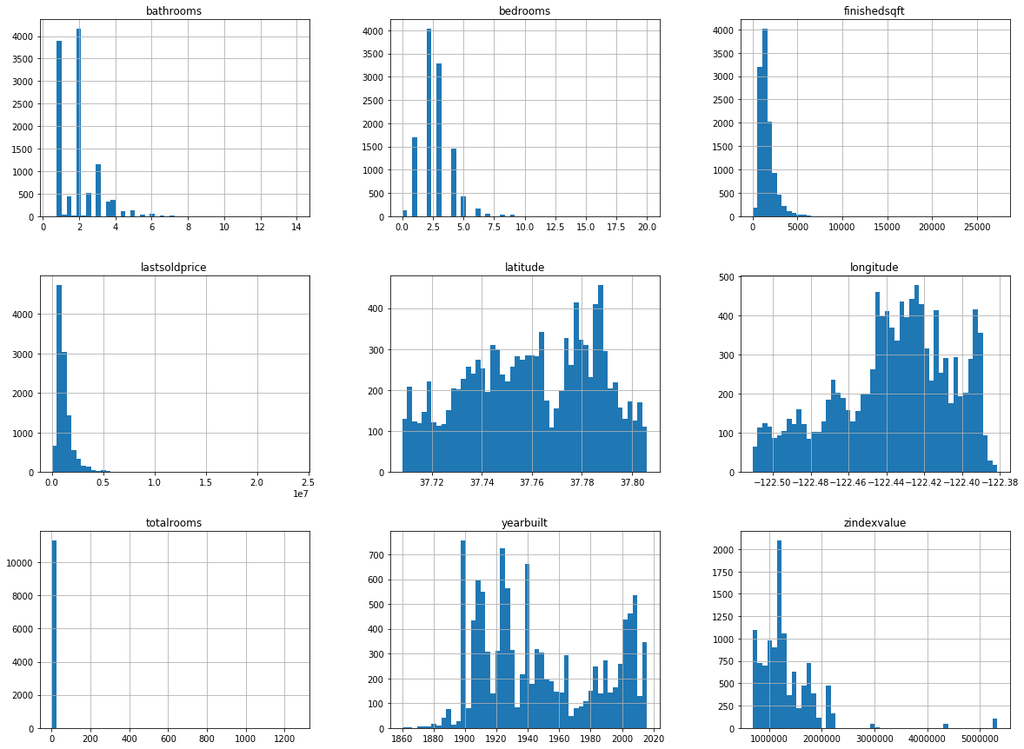

```python
%matplotlib inline
import matplotlib.pyplot as plt
sf.hist(bins=50, figsize=(20,15))
plt.show()
```

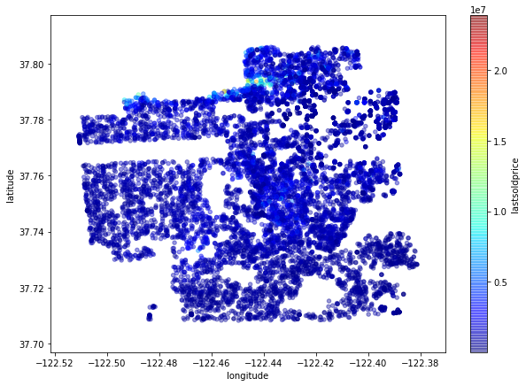

```python
# Now let’s color code from the most expensive to the least expensive areas.
# This image tells us that the most expensive houses sold were in the north area.


sf.plot(kind="scatter", x="longitude", y="latitude", alpha=0.4, figsize=(10,7),
    c="lastsoldprice", cmap=plt.get_cmap("jet"), colorbar=True,
    sharex=False)
```

```python
# The variable we are going to predict is the “last sold price”.
# So let’s look at how much each independent variable correlates with this dependent variable.

'''The last sold price tends to increase when the finished sqft and the number of bathrooms go up.
You can see a small negative correlation between the year built and the last sold price. And finally,
coefficients close to zero indicate that there is no linear correlation.'''

corr_matrix = sf.corr()
corr_matrix["lastsoldprice"].sort_values(ascending=False)
```

```
lastsoldprice    1.000000
finishedsqft     0.647208
bathrooms        0.536880
zindexvalue      0.460429
bedrooms         0.395478
latitude         0.283107
totalrooms       0.093527
longitude       -0.052595
yearbuilt       -0.189055
Name: lastsoldprice, dtype: float64
```

- The last sold price tends to increase when the finished sqft and the number of bathrooms go up.
- You can see a small negative correlation between the year built and the last sold price.
- Coefficients close to zero indicate that there is no linear correlation.

```python
# After performing the above pre-processing, we do not need the following columns anymore:
# “address, lastsolddate, latitude, longitude, neighborhood, price_per_sqft”, so, we drop them from our analysis.

sf.drop(sf.columns[[0, 4, 6, 7, 8]], axis = 1, inplace = True)
sf = sf[['bathrooms', 'bedrooms', 'finishedsqft', 'totalrooms', 'usecode', 'yearbuilt','zindexvalue', 'lastsoldprice']]
sf.head()
```

|  | bathrooms | bedrooms | finishedsqft | totalrooms | usecode | yearbuilt | zindexvalue | lastsoldprice |
| --- | --- | --- | --- | --- | --- | --- | --- | --- |
| 0 | 2.0 | 2.0 | 1043.0 | 4.0 | Condominium | 2007.0 | 975700 | 1300000.0 |
| 1 | 1.0 | 1.0 | 903.0 | 3.0 | Condominium | 2004.0 | 975700 | 750000.0 |
| 2 | 4.0 | 3.0 | 1425.0 | 6.0 | Condominium | 2003.0 | 1277600 | 1495000.0 |
| 3 | 3.0 | 3.0 | 2231.0 | 10.0 | SingleFamily | 1927.0 | 1277600 | 2700000.0 |
| 4 | 3.0 | 3.0 | 1300.0 | 4.0 | SingleFamily | 1900.0 | 1248000 | 1530000.0 |

## Our data looks perfect!

```python
X = sf[['bathrooms', 'bedrooms', 'finishedsqft', 'totalrooms', 'usecode', 'yearbuilt', 'zindexvalue']]

Y = sf['lastsoldprice']
```

```python
sf.usecode.unique()
```

```
array(['Condominium', 'SingleFamily', 'MultiFamily2To4', 'Miscellaneous',
       'Duplex', 'Townhouse', 'Mobile', 'Apartment', 'Cooperative',
       'MultiFamily5Plus'], dtype=object)
```

```python
m = pd.get_dummies(sf.usecode)
X = pd.concat([X, m], axis = 1)

drops = ['usecode']

X.drop(drops, inplace = True, axis = 1)
X.head()
```

|  | bathrooms | bedrooms | finishedsqft | totalrooms | yearbuilt | zindexvalue | Apartment | Condominium | Cooperative | Duplex | Miscellaneous | Mobile | MultiFamily2To4 | MultiFamily5Plus | SingleFamily | Townhouse |
| --- | --- | --- | --- | --- | --- | --- | --- | --- | --- | --- | --- | --- | --- | --- | --- | --- |
| 0 | 2.0 | 2.0 | 1043.0 | 4.0 | 2007.0 | 975700 | 0 | 1 | 0 | 0 | 0 | 0 | 0 | 0 | 0 | 0 |
| 1 | 1.0 | 1.0 | 903.0 | 3.0 | 2004.0 | 975700 | 0 | 1 | 0 | 0 | 0 | 0 | 0 | 0 | 0 | 0 |
| 2 | 4.0 | 3.0 | 1425.0 | 6.0 | 2003.0 | 1277600 | 0 | 1 | 0 | 0 | 0 | 0 | 0 | 0 | 0 | 0 |
| 3 | 3.0 | 3.0 | 2231.0 | 10.0 | 1927.0 | 1277600 | 0 | 0 | 0 | 0 | 0 | 0 | 0 | 0 | 1 | 0 |
| 4 | 3.0 | 3.0 | 1300.0 | 4.0 | 1900.0 | 1248000 | 0 | 0 | 0 | 0 | 0 | 0 | 0 | 0 | 1 | 0 |

# Step 4 : Model data

This is the stage where most people consider interesting... Where the MAGIC happenes

Once again, before reaching this stage, bear in mind that the scrubbing and exploring stage are equally crucial to building useful models. So take your time on those stages instead of jumping right to this process.

```python
from sklearn.model_selection import train_test_split
from sklearn.linear_model import LinearRegression

X_train, X_test, y_train, y_test = train_test_split(X, Y, test_size=0.3, random_state=0)

regressor = LinearRegression()
regressor.fit(X_train, y_train)
```

```
LinearRegression(copy_X=True, fit_intercept=True, n_jobs=None,
         normalize=False)
```

```python
# Let's check model accuracy Root Mean Square Error
import numpy as np
from sklearn.metrics import mean_squared_error

y_pred = regressor.predict(X_test)
lin_mse = mean_squared_error(y_pred, y_test)
lin_rmse = np.sqrt(lin_mse)

print('Linear Regression RMSE: %.4f' % lin_rmse)
```

```
Linear Regression RMSE: 637839.4101
```